# Teaching R

A brief introduction

Kumar Ramanathan kumar.ramanathan@u.northwestern.edu @kumarhk

May 20, 2021

## Warm up

Let’s do some polling! Go to pollev.com/kumarr436

## Learning objectives for today

1. Construct a lesson plan for an R workshop/session
2. Understand the examples-and-exercises approach to teaching R
3. Articulate questions about how to teach R workshops/sessions
4. Identify resources to address those questions

## Outline

- Preparing to teach
- Determining the scope of your lesson
- Building your lesson (nuts-and-bolts)
- Structuring your lesson (what goes after what?)
- Examples and Exercises

# Preparing to teach

## Why should you learn to teach R?

- Teaching is the best way to learn 🤓
- Lots of opportunities to teach R workshops/etc at Northwestern 👩‍🏫
- Build your teaching portfolio 📂
- Training for certain non-academic career paths 💸

## Questions to ask yourself

- What are your **learning objectives** for the course/session/workshop?
- What are the opportunities and constraints you’ll have in your **teaching environment**?
- How much **background** do your students have? How much do they need?

## Learning objectives

- Much of this will be determined by context: the students may need specific skills (e.g. regression, data viz) for a class, you may be teaching general-purpose skills for data analysis, etc.
- I suggest that every R workshop should share two objectives: **Articulate questions about the [technique/method taught]** and **Identify resources to address those questions**.
- In simpler language: you want students to walk away knowing how to ask for help when they run into problems.

## Teaching environment

- One-off workshop vs. series
- Virtual vs. in-person
- Solo teaching vs. group teaching

# Determining the scope of your lesson

## Background knowledge

- What do the students already know? You may be able to answer this from program structure, or through a survey.
- Sometimes students will be coming in with different levels of background knowledge. You can try to address this before the session and/or adjust your teaching accordingly.
- Where can students get background knowledge before the session?
  - Pre-session videos
  - DataQuest
  - `learnr` tutorials

## Do you need to cover the basics? What *are* the basics?

- Installing R and RStudio
- Navigating RStudio
- “code”, “comments”, “objects”
- Syntax and data types
- Data structures
- Reading and writing files

# Building your lesson

## Building your lesson

- Befriend `RMarkdown` (and `RProjects`)
- Consider how to store and share materials: Github, Box folder, something else, none of the above
- Other types of tools: RStudio Cloud
- Connect to other course materials, pre-workshop assignments, etc.

# Structuring your lesson

## Where to start

Motivation

- Use the end point as motivation: show them what they will learn!
- Pick some real data that the students are likely to be interested in

Help students feel comfortable

- Remind them that they are learning a skill, which only comes with practice
- Encourage your students to learn from *each other*

## Core content

I usually outline the core content by:

1. Drafting the end products and breaking down each step.
2. Looking up existing teaching materials on the same/related topic.

I strongly suggest an **examples and exercises** approach to teaching skills in R. We’ll practice this in a moment.

## Building flexibility into your lesson

- Plan for a little bit more material than you can teach
- Provide data files that students can play around with
- For complex skills, give yourself wiggle room to skip over exercises based on timing/interest

## Ending with encouragement

I always like to end with:

1. Main takeaways
2. Resources
3. Reminder that they’ve just learned to create things!

# Examples and Exercises

## Learning by doing

[figure not shown]

## Learning by doing

Open the RProject file and look in the working directory: you will see an `exercises` subdirectory and an `answers` subdirectory.

The following lesson snippets all use `.R` code files for the exercises. You can also ask students to use `.Rmd`, especially if this is part of a course where you will need to collect assignment submissions.

# Lesson snippets

# Lesson snippet 1: ggplot and the grammar of graphics

## Components of a basic plot

- **data**: a data frame, provided to the `ggplot()` function
- **geometric objects**: the objects/shapes that you want to plot, indicated through one of the many available `geom` functions, such as `geom_point()` or `geom_hist()`
- **aesthetic mapping**: the mapping from the data to the geometric objects, provided in an `aes()` function nested within `ggplot()` or a `geom` function
- connected with the `+` operator

```r
ggplot(data = <DATA FRAME>) +
  <GEOM_FUNCTION>(mapping = aes(<VARIABLES>))
```

```r
ggplot(<DATA FRAME>) +
  <GEOM_FUNCTION>(aes(<VARIABLES>))
```

## Prepare data

```r
# Load data
gapminder <- gapminder::gapminder

# Look at the structure of the data. You can use glimpse(), summary(), or head().
glimpse(gapminder)
```

```
## Rows: 1,704
## Columns: 6
## $ country   <fct> "Afghanistan", "Afghanistan", "Afghanistan", "Afghanistan", ~
## $ continent <fct> Asia, Asia, Asia, Asia, Asia, Asia, Asia, Asia, Asia, Asia, ~
## $ year      <int> 1952, 1957, 1962, 1967, 1972, 1977, 1982, 1987, 1992, 1997, ~
## $ lifeExp   <dbl> 28.801, 30.332, 31.997, 34.020, 36.088, 38.438, 39.854, 40.8~
## $ pop       <int> 8425333, 9240934, 10267083, 11537966, 13079460, 14880372, 12~
## $ gdpPercap <dbl> 779.4453, 820.8530, 853.1007, 836.1971, 739.9811, 786.1134, ~
```

```r
# Create a new data frame with only the data for 2007
gapminder07 <- filter(gapminder, year==2007)
```

## A basic scatterplot

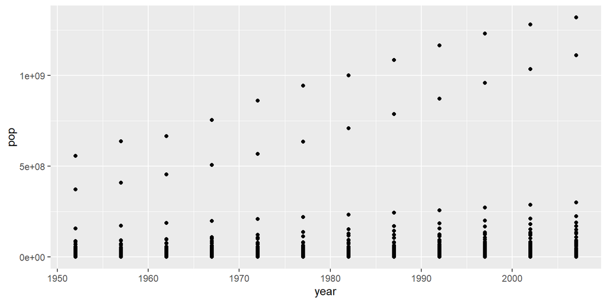

```r
ggplot(gapminder) +
    geom_point(aes(x=year, y=pop))
```

## A basic scatterplot

These will produce the same output:

```r
ggplot(gapminder) +
    geom_point(aes(x=year, y=pop))
```

```r
ggplot(gapminder, aes(x=year, y=pop)) +
    geom_point()
```

## Add labels to the plot

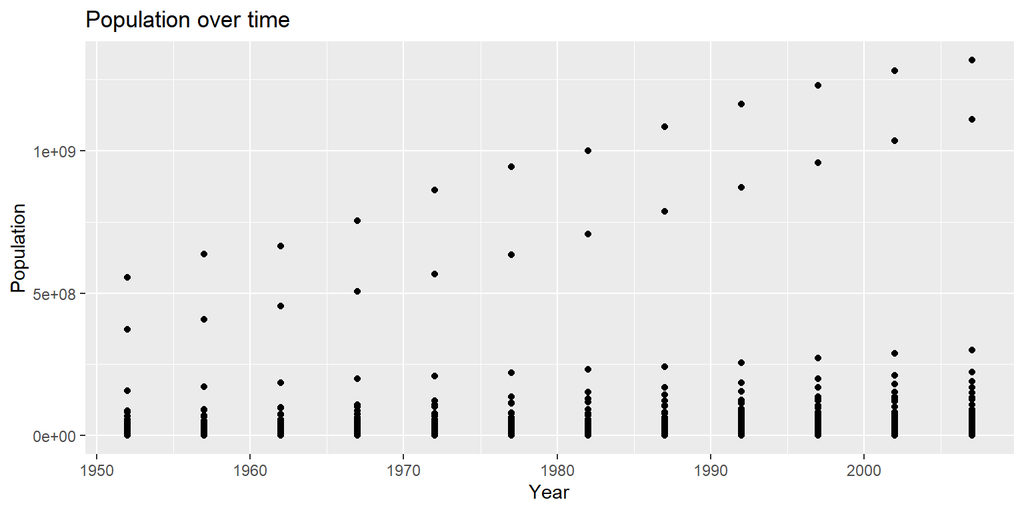

```r
ggplot(gapminder) +
    geom_point(aes(x=year, y=pop)) +
    labs(title="Population over time", x="Year", y="Population")
```

## Your turn!

Plot life expectancy as a function of GDP per capita for the year 2007, and add labels.

- Step 1: Supply the data `gapminder07` to `ggplot()`
- Step 2: Choose `geom_point()` + Supply `x=gdpPercap` and `y=lifeExp` to `aes()`
- Step 3: Add `title`, `x`, and `y` in `labs()`

## Your turn!

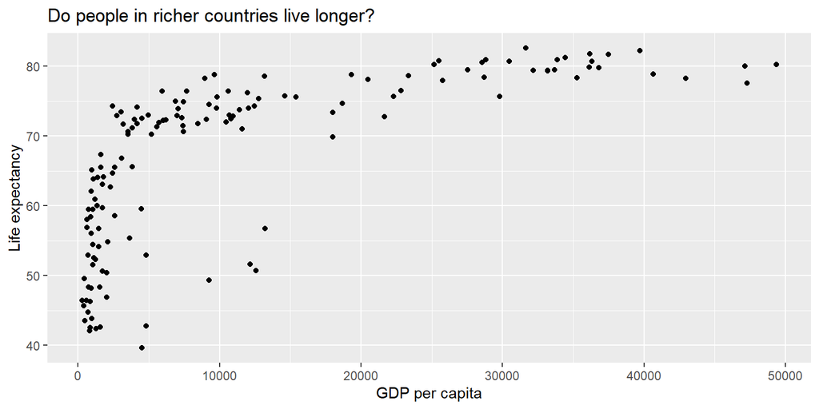

```r
ggplot(gapminder07) +
    geom_point(aes(x=gdpPercap, y=lifeExp)) +
    labs(title="Do people in richer countries live longer?", x="GDP per capita", y="Life expectancy")
```

## Choosing geoms

There are may `geom` functions we can choose to generate geometric objects:

[figure not shown]

Let’s try to add `geom_smooth()` to the previous plot we created.

## Smoothed conditional means

```r
ggplot(gapminder07) +
    geom_point(aes(x=gdpPercap, y=lifeExp)) +
    geom_smooth(aes(x=gdpPercap, y=lifeExp)) +
    labs(title="Do people in richer countries live longer?", x="GDP per capita", y="Life expectancy", subtitle="Gapminder 2007 data")
```

```r
ggplot(gapminder07, aes(x=gdpPercap, y=lifeExp)) +
    geom_point() +
    geom_smooth() +
    labs(title="Do people in richer countries live longer?", x="GDP per capita", y="Life expectancy", subtitle="Gapminder 2007 data")
```

## Smoothed conditional means

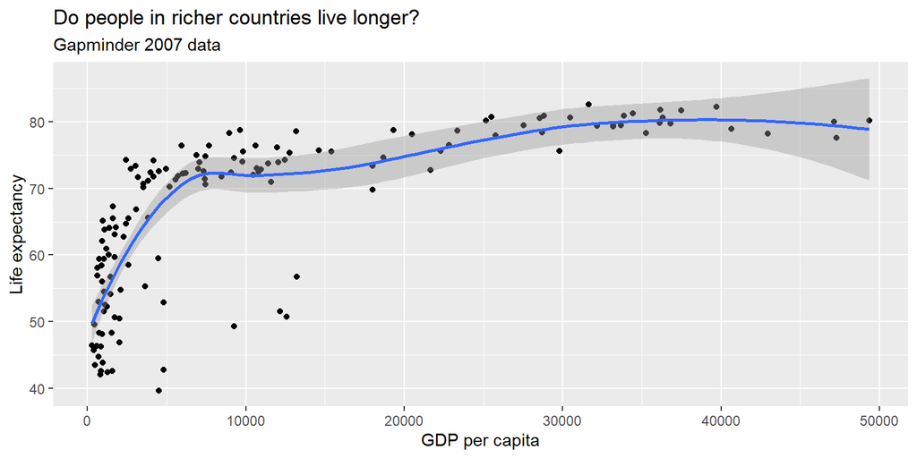

```r
ggplot(gapminder07, aes(x=gdpPercap, y=lifeExp)) +
    geom_point() +
    geom_smooth() +
    labs(title="Do people in richer countries live longer?", x="GDP per capita", y="Life expectancy", subtitle="Gapminder 2007 data")
```

## Horizontal line

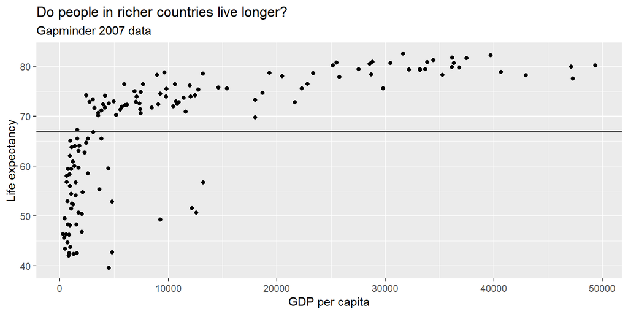

```r
ggplot(gapminder07) +
    geom_point(aes(x=gdpPercap, y=lifeExp)) +
    geom_hline(aes(yintercept=mean(lifeExp))) +
    labs(title="Do people in richer countries live longer?", x="GDP per capita", y="Life expectancy", subtitle="Gapminder 2007 data")
```

## Your turn!

Plot the **life expectancy** of each **continent** in 2007.

Look at the [ggplot cheatsheet](https://raw.githubusercontent.com/rstudio/cheatsheets/master/data-visualization-2.1.pdf) and decide which kind of geom to use.

- Step 1: Supply `gapminder07` to `ggplot()`
- Step 2: Choose a `geom` (e.g. `geom_boxplot()`) and supply appropriate aesthetics in nested `aes()` (e.g. `x=continent, y=lifeExp`)
- Step 3: Add some labels in `labs()`

## Life expectancy in each continent

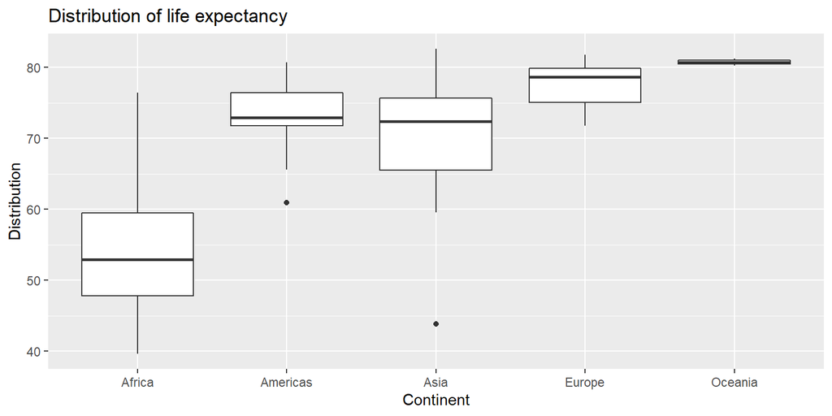

```r
ggplot(gapminder07) +
    geom_boxplot(aes(x=continent, y=lifeExp)) +
    labs(title="Distribution of life expectancy", x="Continent", y="Distribution")
```

## Life expectancy in each continent

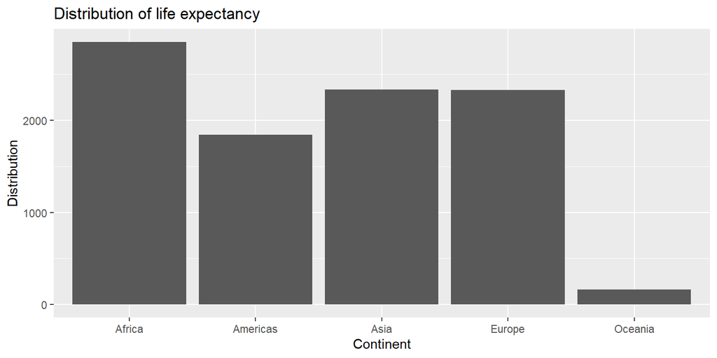

```r
ggplot(gapminder07) +
    geom_col(aes(x=continent, y=lifeExp)) +
    labs(title="Distribution of life expectancy", x="Continent", y="Distribution")
```

## Grouping variables

You can think of the `continent` or `year` variables as **grouping variables**: they place each observation in one of several groups.

We can represent the groups through aesthetic mapping or facets rather than along one of the axes.

## Grouping by color

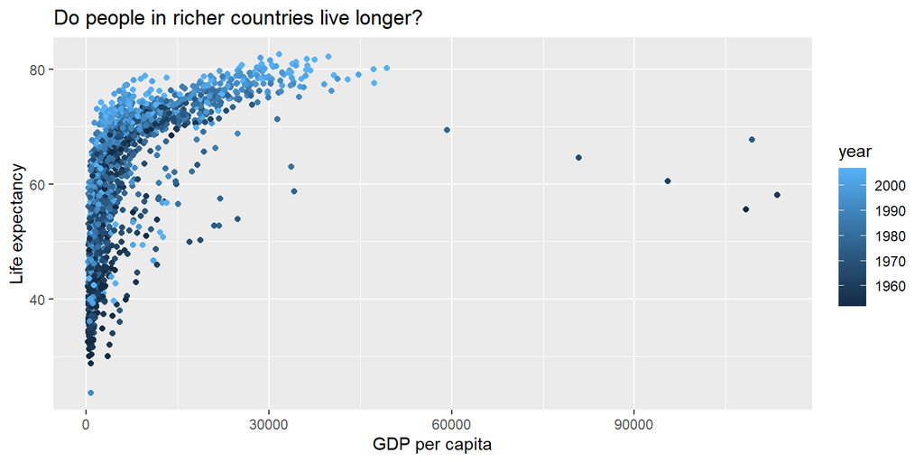

```r
ggplot(gapminder) +
    geom_point(aes(x=gdpPercap, y=lifeExp, col=year)) +
    labs(title="Do people in richer countries live longer?", x="GDP per capita", y="Life expectancy")
```

## Grouping by facet

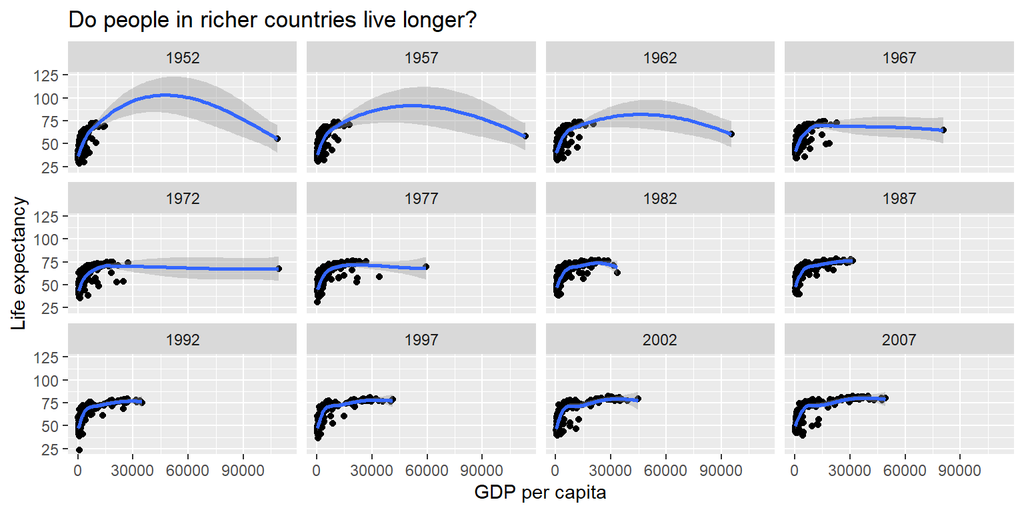

```r
ggplot(gapminder, aes(x=gdpPercap, y=lifeExp)) +
    geom_point() +
    geom_smooth() +
    facet_wrap(~year) +
    labs(title="Do people in richer countries live longer?", x="GDP per capita", y="Life expectancy")
```

## Grouping by facet … scales=“free”

Try adding the argument `scales="free"` to the `facet_wrap()` layer.

## Grouping by facet … scales=“free”

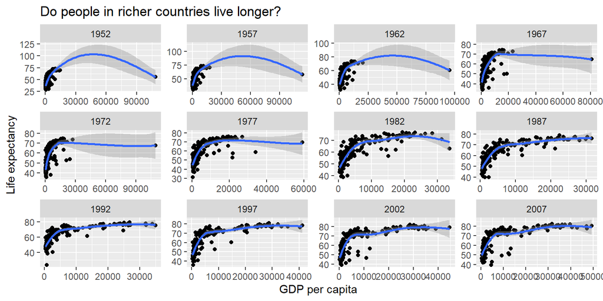

```r
ggplot(gapminder, aes(x=gdpPercap, y=lifeExp)) +
    geom_point() +
    geom_smooth() +
    facet_wrap(~year, scales="free") +
    labs(title="Do people in richer countries live longer?", x="GDP per capita", y="Life expectancy")
```

## Your turn!

Visualize **life expectancy** by continent **in 2007** again. This time, group continents by color or facet.

## Grouping by colors

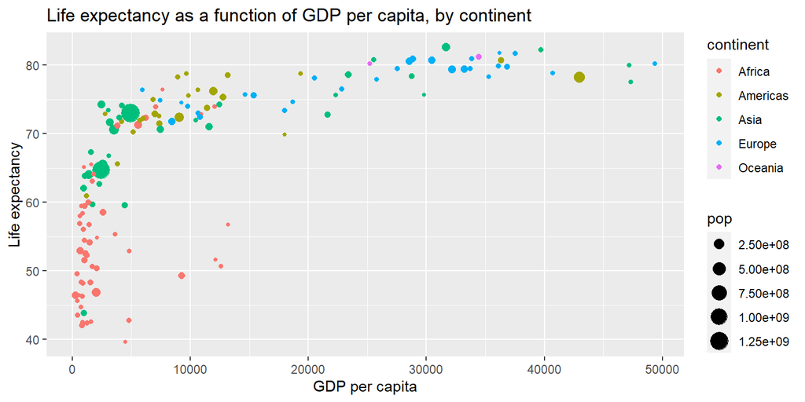

```r
ggplot(gapminder07, aes(x=gdpPercap, y=lifeExp,
                        col=continent, size=pop)) +
    geom_point() +
    labs(title="Life expectancy as a function of GDP per capita, by continent", x="GDP per capita", y="Life expectancy")
```

## Grouping by facet

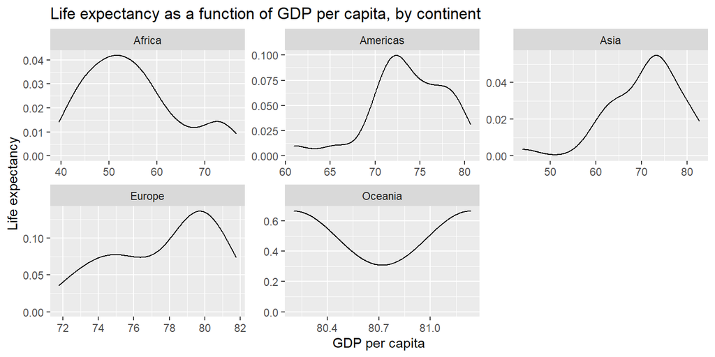

```r
ggplot(gapminder07, aes(x=lifeExp)) +
    geom_density() +
    facet_wrap(~continent, scales="free") +
    labs(title="Life expectancy as a function of GDP per capita, by continent", x="GDP per capita", y="Life expectancy")
```

## Cumulative exercise

Choose your own adventure!

Create a plot that includes **two geoms** and **facets**

# Lesson snippet 2: working with dates

## Prepare libraries and data

```r
# Load tidyverse and lubridate
library(tidyverse)
library(lubridate)

# Import vaccine data
vaccines <- read_csv("data/chicago_vaccines_daily.csv")
# Let's glimpse the data
glimpse(vaccines)
```

```
## Rows: 154
## Columns: 4
## $ date       <chr> "12/15/2020", "12/16/2020", "12/17/2020", "05/16/2021", "05~
## $ doses      <dbl> 16, 157, 1990, 4783, 4697, 5729, 3438, 936, 4385, 3, 3655, ~
## $ first_dose <dbl> 16, 157, 1990, 1719, 1672, 5729, 3438, 936, 4385, 3, 3655, ~
## $ final_dose <dbl> 0, 0, 0, 3140, 3120, 0, 0, 0, 0, 0, 0, 0, 0, 0, 0, 3074, 24~
```

## Working with dates

In your exercise file, check the class of the date variable.

## Working with dates

Check the class of the date variable:

```r
class(vaccines$date)
```

```
## [1] "character"
```

This is just a character string. And it’s not even ordered correctly!

```r
head(vaccines$date)
```

```
## [1] "12/15/2020" "12/16/2020" "12/17/2020" "05/16/2021" "05/17/2021"
## [6] "12/18/2020"
```

## Working with dates

It looks like `as_date()` might be a helpful function from `lubridate`. But what happens when we use it?

```r
as_date(vaccines$date)
```

```
##   [1] NA NA NA NA NA NA NA NA NA NA NA NA NA NA NA NA NA NA NA NA NA NA NA NA NA
##  [26] NA NA NA NA NA NA NA NA NA NA NA NA NA NA NA NA NA NA NA NA NA NA NA NA NA
##  [51] NA NA NA NA NA NA NA NA NA NA NA NA NA NA NA NA NA NA NA NA NA NA NA NA NA
##  [76] NA NA NA NA NA NA NA NA NA NA NA NA NA NA NA NA NA NA NA NA NA NA NA NA NA
## [101] NA NA NA NA NA NA NA NA NA NA NA NA NA NA NA NA NA NA NA NA NA NA NA NA NA
## [126] NA NA NA NA NA NA NA NA NA NA NA NA NA NA NA NA NA NA NA NA NA NA NA NA NA
## [151] NA NA NA NA
```

Whoops! Let’s turn to the `lubridate` [cheatsheet](https://raw.githubusercontent.com/rstudio/cheatsheets/master/lubridate.pdf) for help. What function should we use?

## Converting dates

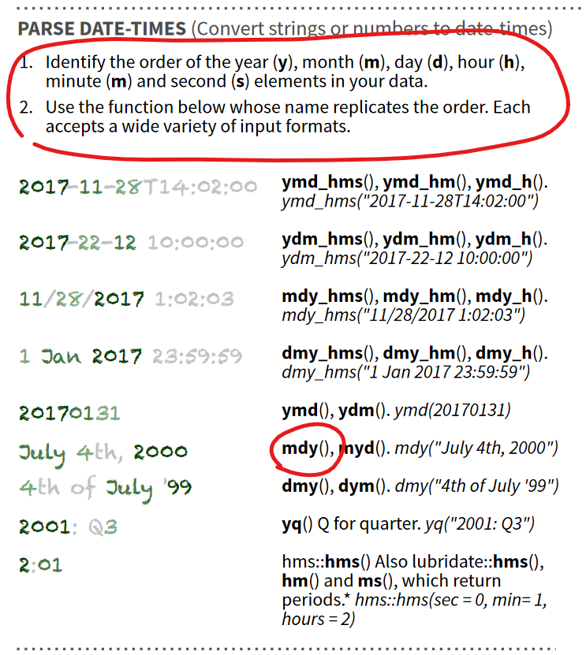

## Converting dates

We can use the tailored `mdy()` function:

```r
mdy(vaccines$date) %>% head()
```

```
## [1] "2020-12-15" "2020-12-16" "2020-12-17" "2021-05-16" "2021-05-17"
## [6] "2020-12-18"
```

```r
as_date(vaccines$date, format="%m/%d/%y") %>% head()
```

```
## [1] "2020-12-15" "2020-12-16" "2020-12-17" "2020-05-16" "2020-05-17"
## [6] "2020-12-18"
```

## Converting dates

```r
# Replace the date variable in the dataset with the converted version
vaccines$date <- mdy(vaccines$date)

# Check the class of our converted variable
class(vaccines$date)
```

```
## [1] "Date"
```

## Utility of the Date format

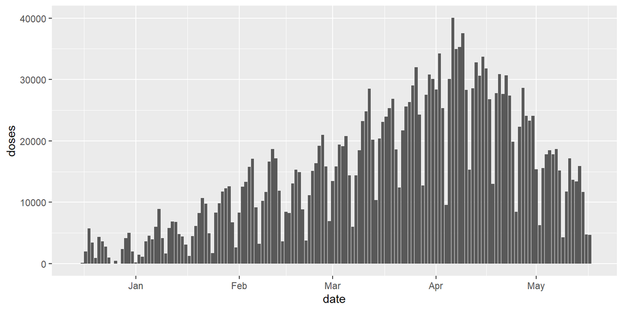

```r
ggplot(vaccines, aes(x=date, y=doses)) + geom_col()
```

## Converting dates

Now, let’s try to convert the `date` variable, which is in `Date` class, into a numeric value for month.

## Converting dates

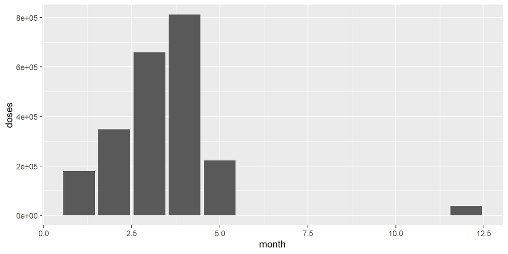

```r
# Create a new variable for month. Refer to the cheatsheet for guidance.
vaccines$month <- month(vaccines$date)

# Repeat the plot, using month as the x-axis
ggplot(vaccines, aes(x=month, y=doses)) + geom_col()
```

## Converting dates

How about if we want to get the *day of the week*? Identify the right function using the `lubridate` cheatsheet. Check the help file to see if there are any useful arguments.

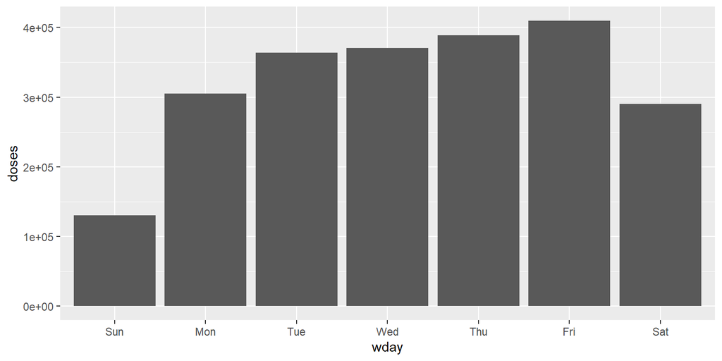

```r
# Create a new variable for day of the week, with label=TRUE
vaccines$wday <- wday(vaccines$date, label=TRUE)

# Repeat the plot, using day of the week as the x-axis
ggplot(vaccines, aes(x=wday, y=doses)) + geom_col()
```

## Working with dates

Bonus exercise if time permits: Can you calculate the number of days it took for Chicago to fully vaccinate 1 million people?

Hint: You may need to ue the function `cumsum()`

# Lesson snippet 3: regression and coefplot

## Regression models in R

Let’s use the `gapminder` data that we are already familiar with to practice implementing some **linear regressions** and examining the results.

## Preparing data

```r
# Import data
gapminder <- gapminder::gapminder

# Examine data
glimpse(gapminder)
```

```
## Rows: 1,704
## Columns: 6
## $ country   <fct> "Afghanistan", "Afghanistan", "Afghanistan", "Afghanistan", ~
## $ continent <fct> Asia, Asia, Asia, Asia, Asia, Asia, Asia, Asia, Asia, Asia, ~
## $ year      <int> 1952, 1957, 1962, 1967, 1972, 1977, 1982, 1987, 1992, 1997, ~
## $ lifeExp   <dbl> 28.801, 30.332, 31.997, 34.020, 36.088, 38.438, 39.854, 40.8~
## $ pop       <int> 8425333, 9240934, 10267083, 11537966, 13079460, 14880372, 12~
## $ gdpPercap <dbl> 779.4453, 820.8530, 853.1007, 836.1971, 739.9811, 786.1134, ~
```

```r
# Create GDP per capita (per thousand dollars) variable
gapminder$gdpPercap_perthou <- gapminder$gdpPercap/1000
```

## Life expectancy and GDP per capita

Are life expectancy and GDP per capita related? A scatterplot suggests … maybe! We can investigate the relationship in a different way with a regression.

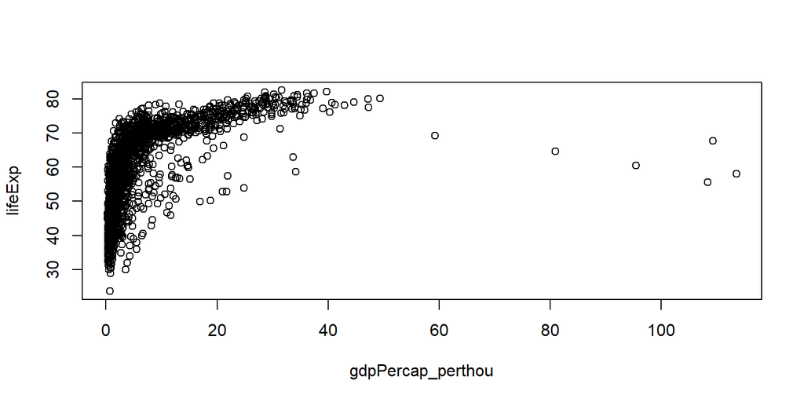

```r
plot(lifeExp ~ gdpPercap_perthou, data=gapminder)
```

## Implementing a regression

The `lm()` function in base R takes a formula and an argument specifying the data frame:

```r
lm(formula = DEP_VAR ~ IV1 + IV2, data = DATAFRAME)
```

Let’s implement a regression with the DV `lifeExp` and one IV, `gdpPercap`. We’ll save the results as `mod1`. Look at what the object class is in your environment.

```r
mod1 <- lm(lifeExp ~ gdpPercap_perthou, data=gapminder)
```

## Examining regression results

We can print out the results using `summary()` on the saved list object.

```r
summary(mod1)
```

```
##
## Call:
## lm(formula = lifeExp ~ gdpPercap_perthou, data = gapminder)
##
## Residuals:
##     Min      1Q  Median      3Q     Max
## -82.754  -7.758   2.176   8.225  18.426
##
## Coefficients:
##                   Estimate Std. Error t value Pr(>|t|)
## (Intercept)       53.95556    0.31499  171.29   <2e-16 ***
## gdpPercap_perthou  0.76488    0.02579   29.66   <2e-16 ***
## ---
## Signif. codes:  0 '***' 0.001 '**' 0.01 '*' 0.05 '.' 0.1 ' ' 1
##
## Residual standard error: 10.49 on 1702 degrees of freedom
## Multiple R-squared:  0.3407, Adjusted R-squared:  0.3403
## F-statistic: 879.6 on 1 and 1702 DF,  p-value: < 2.2e-16
```

## Your turn! A multivariate model

Implement a regression with the DV `lifeExp` and the IVs `gdpPercap` and `year`.

Then examine the results using `summary()`.

## A multivariate model

```r
mod2 <- lm(lifeExp ~ gdpPercap_perthou + year, data=gapminder)

summary(mod2)
```

```
##
## Call:
## lm(formula = lifeExp ~ gdpPercap_perthou + year, data = gapminder)
##
## Residuals:
##     Min      1Q  Median      3Q     Max
## -67.262  -6.954   1.219   7.759  19.553
##
## Coefficients:
##                     Estimate Std. Error t value Pr(>|t|)
## (Intercept)       -418.42426   27.61714  -15.15   <2e-16 ***
## gdpPercap_perthou    0.66973    0.02447   27.37   <2e-16 ***
## year                 0.23898    0.01397   17.11   <2e-16 ***
## ---
## Signif. codes:  0 '***' 0.001 '**' 0.01 '*' 0.05 '.' 0.1 ' ' 1
##
## Residual standard error: 9.694 on 1701 degrees of freedom
## Multiple R-squared:  0.4375, Adjusted R-squared:  0.4368
## F-statistic: 661.4 on 2 and 1701 DF,  p-value: < 2.2e-16
```

## Examining regression results

Alternatively, we can visualize the coefficients and uncertainty using `coefplot()`. But the below isn’t very easy to read. What can we do to improve it? Check out the help file.

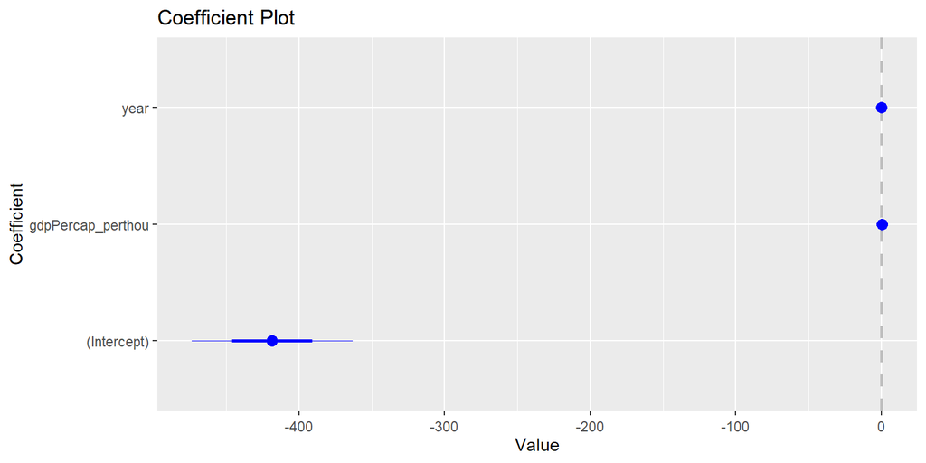

```r
coefplot(mod2)
```

## Examining regression results

We can remove the intercept using the argument `intercept=FALSE`.

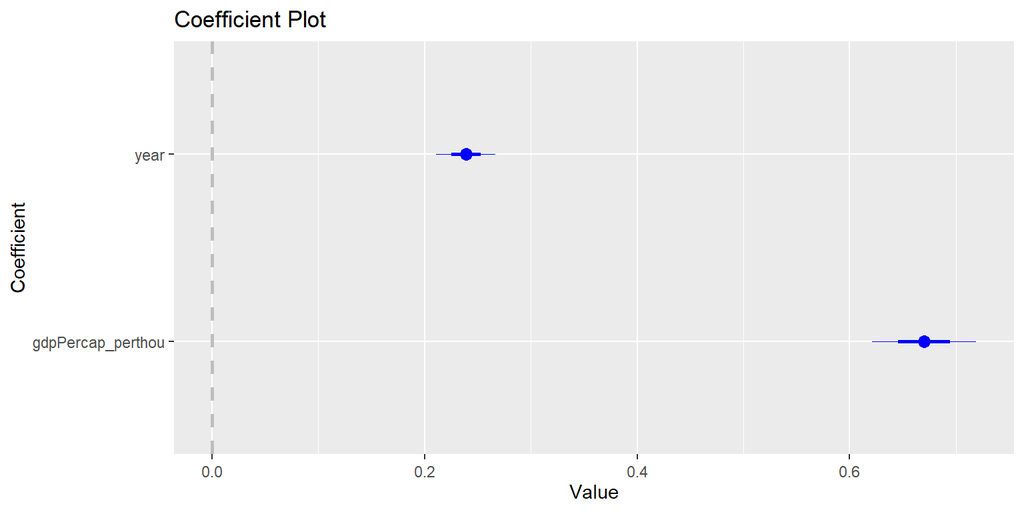

```r
coefplot(mod2, intercept=FALSE)
```

## Add a title to the plot

```r
coefplot(mod2, intercept=FALSE, title="Coefficients from Model 2")
```

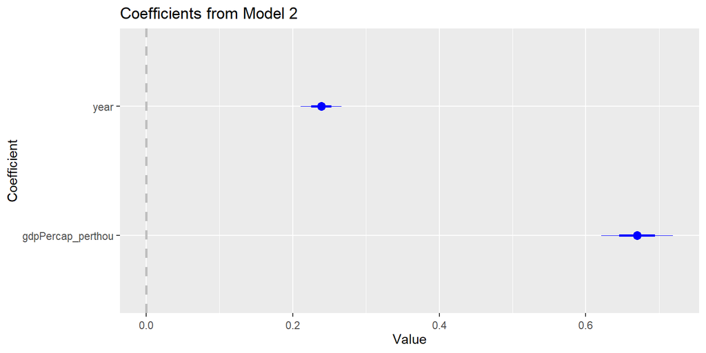

```r
coefplot(mod2, intercept=FALSE) + labs(title="Coefficients from Model 2")
```

## One more multivariate model

Predict life expectancy as a function of GDP per capita, year, and continent.

## One more multivariate model

```r
mod3 <- lm(lifeExp ~ gdpPercap_perthou + year + continent, data=gapminder)

summary(mod3)
```

```
##
## Call:
## lm(formula = lifeExp ~ gdpPercap_perthou + year + continent,
##     data = gapminder)
##
## Residuals:
##      Min       1Q   Median       3Q      Max
## -28.4264  -4.0725   0.2154   4.4853  19.9977
##
## Coefficients:
##                     Estimate Std. Error t value Pr(>|t|)
## (Intercept)       -520.67458   19.79081  -26.31   <2e-16 ***
## gdpPercap_perthou    0.29675    0.01996   14.87   <2e-16 ***
## year                 0.28739    0.01000   28.73   <2e-16 ***
## continentAmericas   14.32676    0.49358   29.03   <2e-16 ***
## continentAsia        9.50561    0.45670   20.81   <2e-16 ***
## continentEurope     19.39554    0.51730   37.49   <2e-16 ***
## continentOceania    20.58592    1.46895   14.01   <2e-16 ***
## ---
## Signif. codes:  0 '***' 0.001 '**' 0.01 '*' 0.05 '.' 0.1 ' ' 1
##
## Residual standard error: 6.884 on 1697 degrees of freedom
## Multiple R-squared:  0.717,  Adjusted R-squared:  0.716
## F-statistic: 716.6 on 6 and 1697 DF,  p-value: < 2.2e-16
```

## One more multivariate model

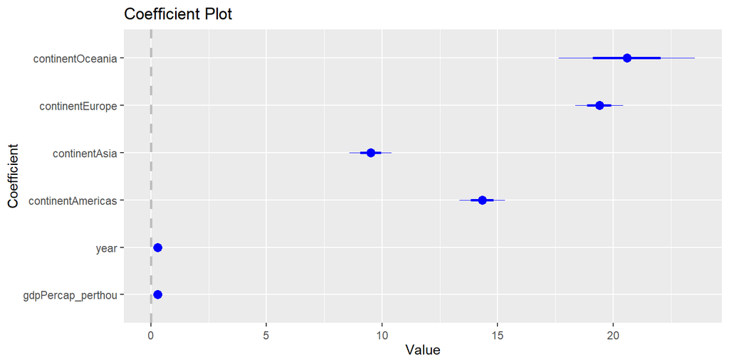

```r
coefplot(mod3, intercept=F)
```

# Wrapping up

## Takeaways

1. Lesson planning is really important: Develop learning objectives. Assess what your students already know + what they need.
2. Use the tools that R provides: `RMarkdown`, `RProjects`, and `RStudio` itself.
3. Construct your lessons around examples and exercises, so that students practice writing code *during* the session.
4. Lean on the broad community of R users and social scientists. You almost never have to start from scratch.

## Resources

Examples from NU:

- [NUIT Research Computing Services workshops](https://github.com/nuitrcs)
- [Masters of Science in Analytics boot camps](https://github.com/msia/bootcamp-2019)
- [Amanda d’Urso’s tutorials and workshops](https://sites.northwestern.edu/asdurso/r/)

Other resources:

- [Library of free learning resources](https://sites.northwestern.edu/researchcomputing/category/learning-resources/), from NUIT RCS
- [Compilation of resources often used by social scientists](https://efarristcu.medium.com/teaching-myself-r-c03c52361bed), from Emily Farris
- [`learnr` interactive tutorials](https://rstudio.github.io/learnr/), from RStudio
- [Dataquest](https://www.it.northwestern.edu/research/campus-events/data-camp.html) (coursework license available from NUIT)

Take it to the next level (suggestions from Christina Maimone):

- [“Teaching Tech Together”](https://teachtogether.tech/) + [Carpentries Instructor Training](https://carpentries.github.io/instructor-training/)

## You can do it!

[figure not shown]